# Problem Set 1 - Computational Problems

Ryan Denton

10/14/21

```r
library(pacman)

p_load(tidyverse)

library(readxl)
EC320_ps1 <- read_excel("EC320_ps1.xlsx")
```

Question #1

```r
EC320_ps1 <- EC320_ps1%>%
  mutate(percent_trump_percounty = trump_votes/total_votes)



EC320_ps1 <- EC320_ps1%>%
  mutate(percent_biden_percounty = biden_votes/total_votes)


EC320_ps1 <- EC320_ps1%>%
  mutate(trump_margin_percounty = percent_trump_percounty- percent_biden_percounty)
```

Question #2

```r
summary(EC320_ps1)
```

```
##       fips          state              county           total_votes
##  Min.   : 1001   Length:3099        Length:3099        Min.   :     66
##  1st Qu.:19030   Class :character   Class :character   1st Qu.:   5351
##  Median :29189   Mode  :character   Mode  :character   Median :  12477
##  Mean   :30548                                         Mean   :  50705
##  3rd Qu.:45072                                         3rd Qu.:  33629
##  Max.   :56045                                         Max.   :4264365
##   trump_votes       biden_votes       poverty_rate     population
##  Min.   :     60   Min.   :      4   Min.   : 2.70   Min.   :     169
##  1st Qu.:   3671   1st Qu.:   1284   1st Qu.:10.50   1st Qu.:   11090
##  Median :   8312   Median :   3661   Median :13.40   Median :   26010
##  Mean   :  23810   Mean   :  25943   Mean   :14.48   Mean   :  105258
##  3rd Qu.:  20826   3rd Qu.:  12092   3rd Qu.:17.50   3rd Qu.:   69442
##  Max.   :1145530   Max.   :3028885   Max.   :47.70   Max.   :10039107
##  pct_bachelors_degree percent_trump_percounty percent_biden_percounty
##  Min.   : 0.00        Min.   :0.0873          Min.   :0.03091
##  1st Qu.:15.30        1st Qu.:0.5595          1st Qu.:0.20889
##  Median :19.50        Median :0.6840          Median :0.29918
##  Mean   :21.91        Mean   :0.6512          Mean   :0.33124
##  3rd Qu.:25.90        3rd Qu.:0.7752          3rd Qu.:0.42116
##  Max.   :77.60        Max.   :0.9618          Max.   :0.89256
##  trump_margin_percounty
##  Min.   :-0.8053
##  1st Qu.: 0.1378
##  Median : 0.3859
##  Mean   : 0.3200
##  3rd Qu.: 0.5663
##  Max.   : 0.9309
```

Question 2a.

Trump’s average/mean vote margin was 0.3200

Question 2b.

The meadian poverty rate was 13.40

Question 2c

169 people live in the least populous county

10039107 people live in the most populous county

#Question 3

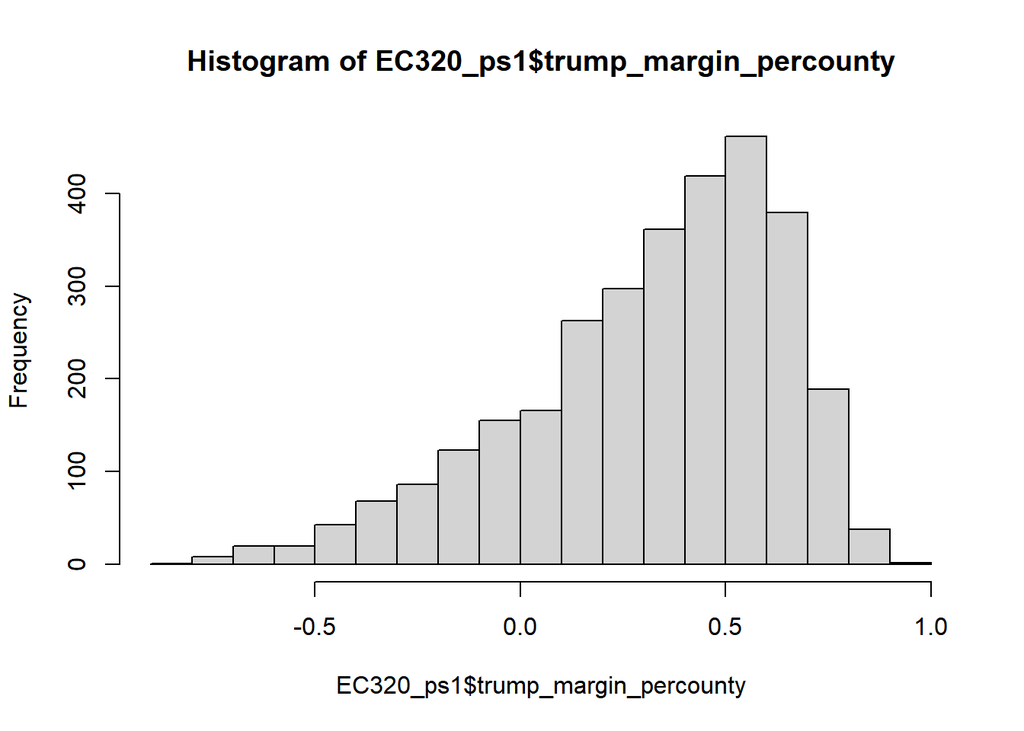

```r
hist(EC320_ps1$trump_margin_percounty)
```

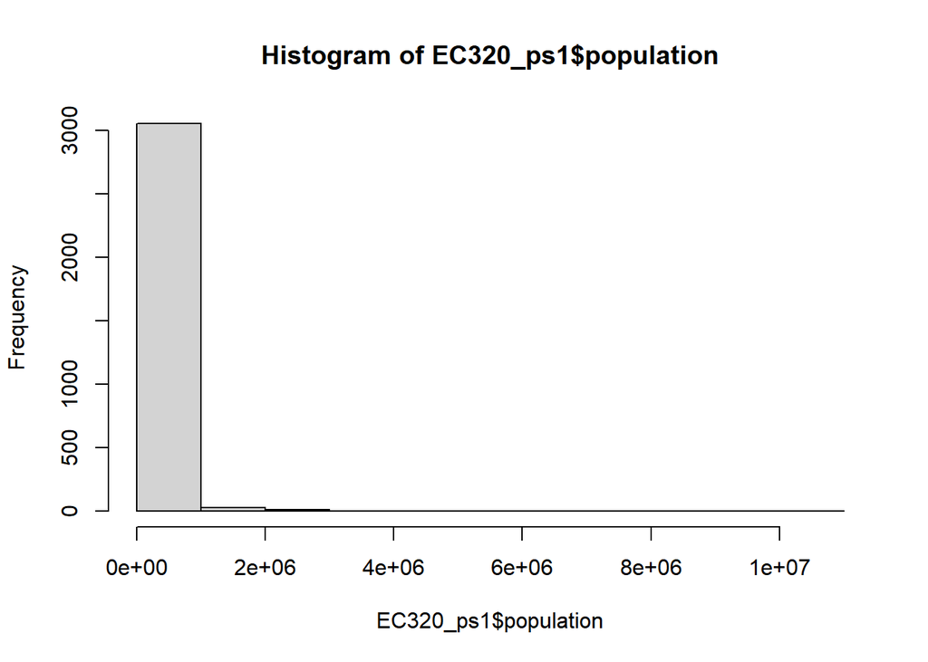

```r
hist(EC320_ps1$population)
```

Even though trump had a higher margin of victory for a lot more counties, we can see that the counties are mostly small ones. And so even though trump won more counties, biden could still have more votes nationally by winning counties of larger sizes.

Question 4

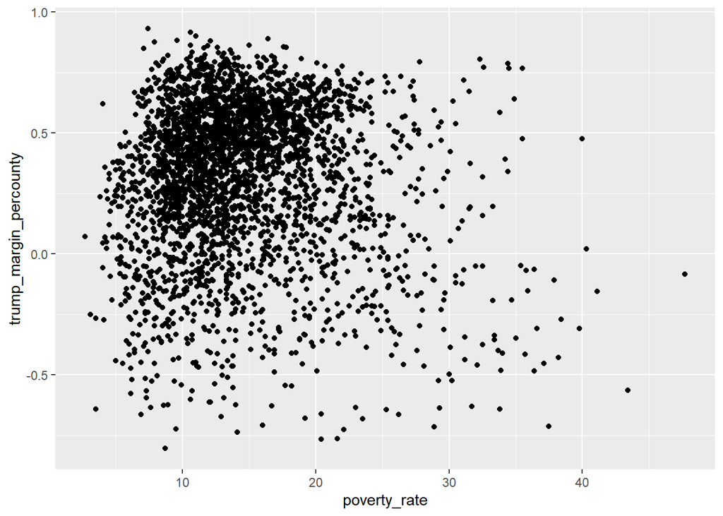

```r
ggplot(data = EC320_ps1, mapping = aes(x = poverty_rate, y = trump_margin_percounty))+
  geom_point()
```

```r
cor(EC320_ps1$poverty_rate, EC320_ps1$trump_margin_percounty)
```

```
## [1] -0.06355671
```

The correlation coefficient here is -0.06355671. This means there is a VERY weak, if any, relationship between these two variables. This can also be seen visually, it just looks like a huge random assortment of dots without any linearity visible at all. So I would say that we couldn’t conclude much from this graph.

Question 5

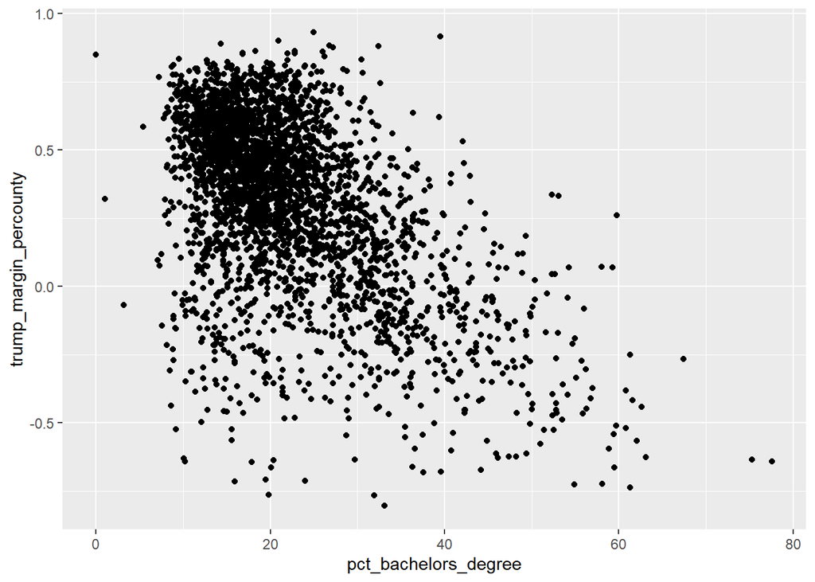

```r
ggplot(data = EC320_ps1, mapping = aes(x = pct_bachelors_degree  , y = trump_margin_percounty))+
  geom_point()
```

```r
cor(EC320_ps1$pct_bachelors_degree, EC320_ps1$trump_margin_percounty)
```

```
## [1] -0.5301196
```

Now in this one we can see there seems to be a negative relationship between these two variables. This is confirmed by the correlation coefficient value of -0.5301196. This means there is a moderate negative relationship, indicating that the data shows that as the number of individuals with bachelors degrees in a county goes up, trump’s margin of victory goes down.

Question 6

```r
state_data <- EC320_ps1 %>%
  group_by(state) %>%
  summarize(poverty = weighted.mean(x = poverty_rate, w = population),
            bachelors_degree = weighted.mean(x = pct_bachelors_degree, w = population),
            population = sum(population))
```

Question 7

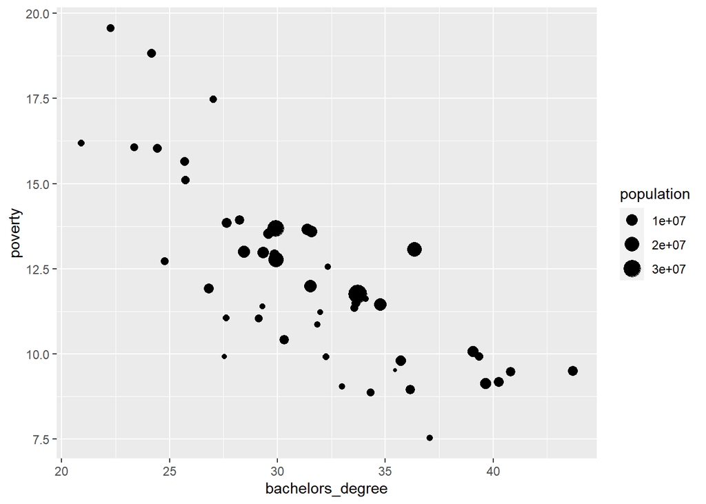

```r
ggplot(data = state_data, mapping = aes(x = bachelors_degree  , y = poverty, size = population))+
  geom_point()
```

```r
cor(state_data$bachelors_degree, state_data$poverty)
```

```
## [1] -0.7701145
```

I notice a negative correlation visually, which is confirmed when finding the correlation coefficient of -0.77. This indicates a strong negative relationship between these two variable. Which intuitively makes sense, the higher the number of people with bachelors degrees then the lower the poverty rate will be.Higher rates of higher educated people leads to higher levels of income in that state and therefore lower poverty rates.